# Title: Budget, Genre, and Profit Trends: An Analytical Report on Movie Profitability

# Pivot table & Visualization of Top Production Companies by Profit

```python
df.pivot_table(values='profit', index='production_companies', aggfunc='mean')
```

| production_companies | profit |
| --- | --- |
| 1492 Pictures, Dune Entertainment, Fox 2000 Pictures, Sunswept Entertainment, Dune Entertainment III, TSG Entertainment | 8.457875e+07 |
| 1492 Pictures, Heyday films, Warner Bros. | 7.182465e+08 |
| 1492 Pictures, Warner Bros., Heyday Films | 8.514756e+08 |
| Aardman Animations, DreamWorks Animation | -8.454068e+07 |
| Alcon Entertainment, Madhouse Entertainment, 8:38 Productions | 7.612669e+07 |
| ... | ... |
| WingNut Films, New Line Cinema | 1.024889e+09 |
| WingNut Films, New Line Cinema, The Saul Zaentz Company | 8.128279e+08 |
| WingNut Films, New Line Cinema, Warner Bros. Pictures, 3Foot7, Metro-Goldwyn-Mayer (MGM) | 7.060198e+08 |
| WingNut Films, New Line Cinema, Warner Bros. Pictures, Metro-Goldwyn-Mayer (MGM) | 7.397518e+08 |
| WingNut Films, Universal Pictures, Big Primate Pictures, MFPV Film | 3.430000e+08 |

852 rows × 1 columns

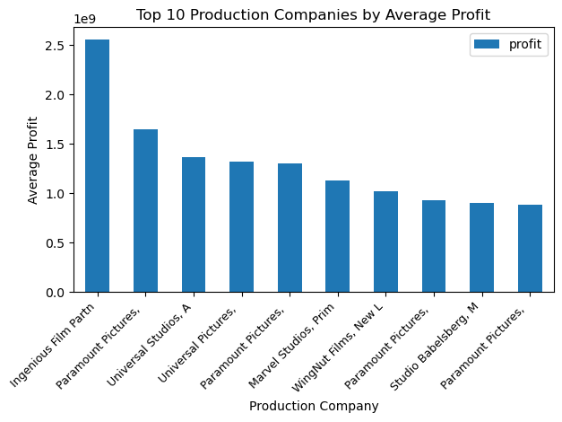

```python
import warnings
warnings.filterwarnings('ignore')

top_companies = df.pivot_table(
    values='profit',
    index='production_companies',
    aggfunc='mean'
).sort_values(by='profit', ascending=False).head(10)

#Short names (first 20 characters)
top_companies.index = top_companies.index.str[:20]

top_companies.plot(kind='bar')

plt.title('Top 10 Production Companies by Average Profit')
plt.xlabel('Production Company')
plt.ylabel('Average Profit')
plt.xticks(rotation=45, ha='right', fontsize=9)
plt.tight_layout()
plt.show()
```

**Explanation:A pivot table was used to calculate the average profit for each production company based on their collaborations. The results were then sorted to identify the highest earning production companies.The top 10 production companies were visualised using a bar chart to provide a clear comparison of their average profits. This helps in easily identifying which production companies generate the highest financial returns in the dataset.**

# Budget vs Profit

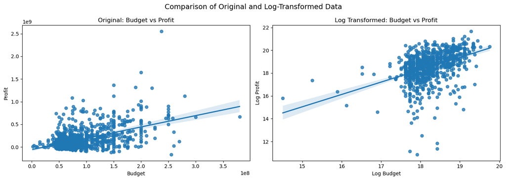

```python
import matplotlib.pyplot as plt
import seaborn as sns

fig, axes = plt.subplots(1, 2, figsize=(14, 5))

# Original
sns.regplot(x='budget', y='profit', data=df, ax=axes[0])
axes[0].set_title("Original: Budget vs Profit")
axes[0].set_xlabel("Budget")
axes[0].set_ylabel("Profit")

# Log transformed
sns.regplot(x='log_budget', y='log_profit', data=df, ax=axes[1])
axes[1].set_title("Log Transformed: Budget vs Profit")
axes[1].set_xlabel("Log Budget")
axes[1].set_ylabel("Log Profit")

plt.suptitle("Comparison of Original and Log-Transformed Data", fontsize=14)

plt.tight_layout()
plt.show()
```

**The original data is highly skewed and dominated by extreme values, while log transformation reduces skewness and makes the data more balanced and easier to interpret, revealing a clearer relationship between budget and profit.**